# A brief introduction to the General Lake Model

### Overview:

1. A physical limnology refresher
2. What is the General Lake Model?
3. What inputs are required?
4. Walk through an example GLM run
5. Assess model outputs
6. Downloads and support

### Physical limno refresher

Let’s conduct a mental excercise. Imagine a lake a couple days after ice-off. The water temperatures are isothermic from top to bottom. Now imagine this lake a few months later in the middle of summer. What are the main differences between these two time points? That’s right the heat content is the major difference. So how does a lake gain heat? Specifically what are the sources of heat to a lake and processes that move the heat form one location to another? List them.

OK. Now imagine your mid-summer lake. It is thermally stratified with warm less dense water above and cold dense water below. In a few months from now the lake will have lost its heat and will again be isothermic. How did the lake lose all this heat? List the heat sinks and processes that facilitate heat loss.

### What is the GLM?

The General Lake Model is a one dimensional hydrodynamic model that is useful for simulation of thermal stratification, lake levels, etc. and couples with biogeochemical lake models. The model assumes horozontal homogeneity.

[figure not shown]

### What inputs are required?

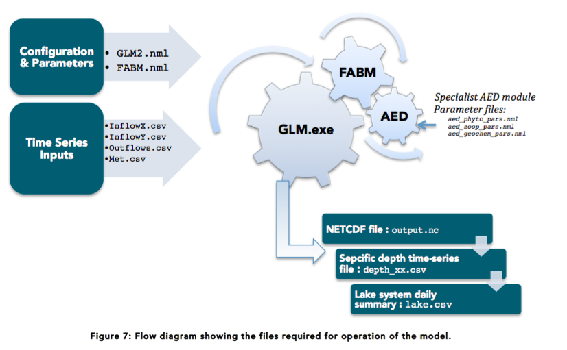

### Example model run

Problem: We artificially destratified Crystal Lake in 2012 and thereby drastically altered the thermal regime of the lake. What would the thermal regime of Crystal Lake have looked like in 2012 had we not mixed it?

Workflow:

1. Identify relevant drivers of water temperature for Crystal Lake (not all lakes are the same!).
2. Compile relevant drivers into GLM input file “MET.csv”.
3. Set up configuration file (GLM2.nml) for model run.
4. Run GLM

### Assess simulation outputs

OK. So we have successfully run the model, now are the outputs any good? We can assess performance of the simulated water temperatures if we have water temperature profiles to validate the model outputs to. We can compare the surface and bottom water temperatures of the simulation to the measured profiles, or we can calculate higher order physical indicies for both the simulated data and measurements and compare them.

Work flow:

1. Use the LakeAnalyzer software package to calculate the depth of the thermocline for the observed data.
2. Use LakeAnalyzer to calculate thermocline depth for simulated data.
3. Calculate RMSE between observed and measured data. Is the RMSE defensible?
4. Revisit the GLM2.nml file (configuration file) and adjust some parameters and run the model again. The process of optimizing model parameters is a bit of work the GLM community is actively working on. The automation code isn’t too far from being available.

### Model download and support

There are a lot of people out there using this open source tool and a few of them may be your neighbors. Below are a set of links for downloads, support, and tools to make your General Lake Model experience successful.

Download binary or source files (Windows, Ubuntu, Macintosh): http://aed.see.uwa.edu.au/research/models/GLM/Pages/download_bin.php

Download GLM as an R package that you can run from the R environment. If you go this route then you can use “glmtools” (a sweet suite of code) that helps control model runs and assess model performance: https://github.com/GLEON/GLMr

Get the GLM user manual here: http://aed.see.uwa.edu.au/research/models/GLM/Pages/documentation.html

A discussion forum of model users and developers: https://sites.google.com/site/aquaticmodelling/home

Good luck! … not that you need it